# Donor Profile: Belgian Development Cooperation

## Focus Portfolio

Belgian Development Cooperation’s portfolio reveals a concentrated funding landscape where the median contribution stands at approximately 1.7 million USD, but some projects receive over 21 million USD, indicating strategic prioritization. This concentration suggests an opportunity to leverage existing high-value investments as impact multipliers by scaling successful initiatives. Notably, the considerable funding variance highlights untapped areas where incremental funding could yield significant returns, especially in underinvested UNHCR regions with rising humanitarian needs. To capitalize on this, donors should view additional contributions as strategic investments that optimize resource allocation for maximum impact. Enhancing partnerships around well-resourced projects can accelerate emergency response and resilience building, aligning with donor priorities for accountability and innovation. Immediate executive action is warranted to identify and amplify high-potential projects, mitigating risks related to funding gaps and improving overall portfolio effectiveness. Mobilizing resources now will strengthen Belgium’s catalytic role and create scalable models for sustainable impact.

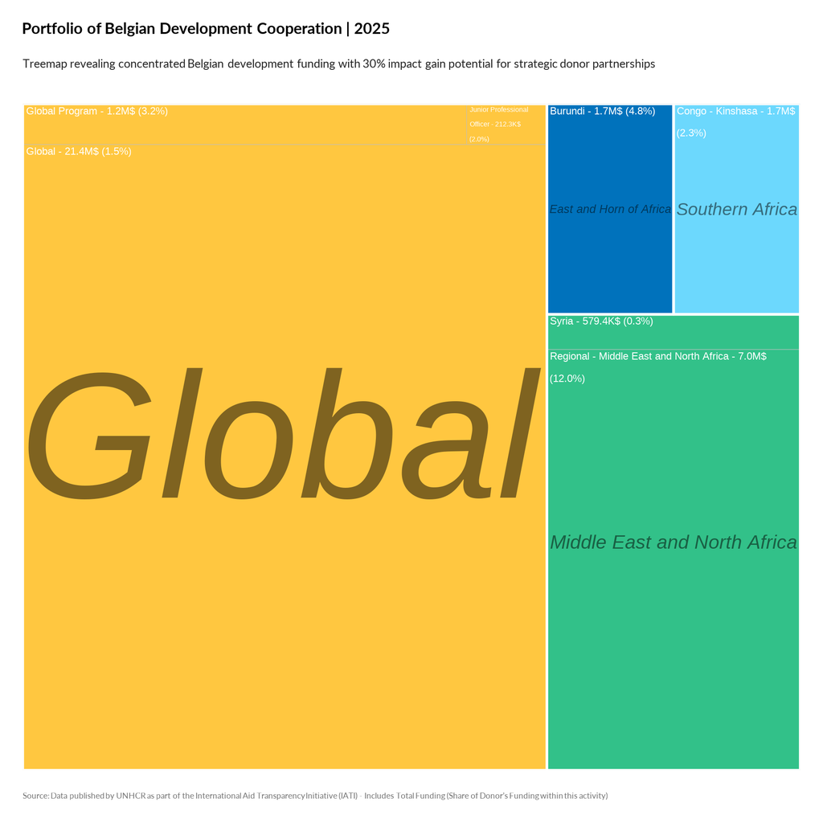

TRUE

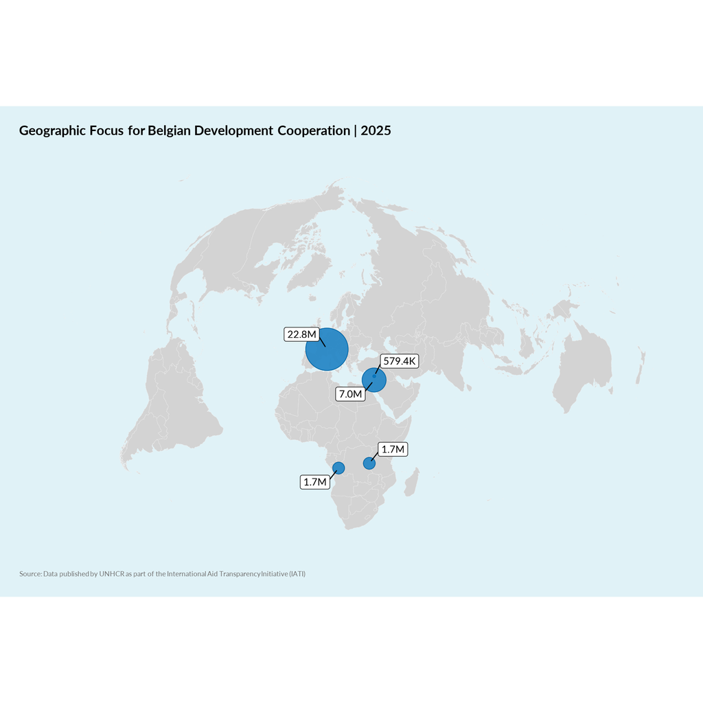

TRUE